# Hypotheses Testing

Alan Arnholt

2015-10-21

Generating some random data:

```r
set.seed(params$seed)
score <- c(rnorm(25, 95, 15), rnorm(25, 105, 15))
school <- gl(n = 2, k = 25, labels = c("Blowing Rock", "Hardin Park"))
DF <- data.frame(score = score, school = school)
```

Test whether the mean IQ score is the same for Blowing Rock and Hardin Park versus whether the mean IQ score for Blowing Rock is $\neq$ the mean IQ score for Hardin Park.

$H_0: \mu_{Blowing Rock} = \mu_{Hardin Park}$ versus $H_1: \mu_{Blowing Rock} \neq \mu_{Hardin Park}$

Graphs first:

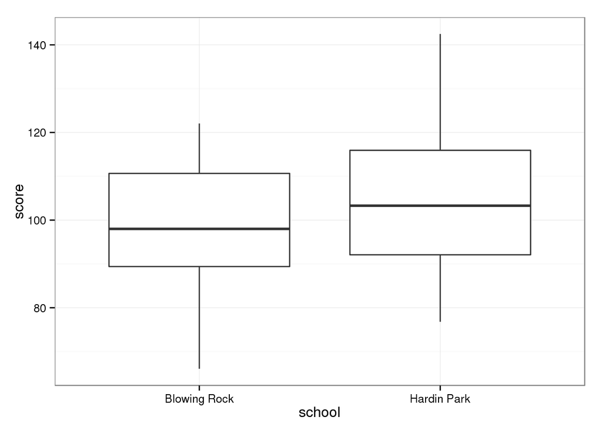

```r
library(ggplot2)
ggplot(data = DF, aes(x = school, y = score)) +
  geom_boxplot() +
  theme_bw()
```

Test next:

```r
TR <- t.test(score ~ school, data = DF, var.equal = TRUE, alt = params$alt)
TR
```

```
    Two Sample t-test

data:  score by school
t = -1.7003, df = 48, p-value = 0.09555
alternative hypothesis: true difference in means is not equal to 0
95 percent confidence interval:
 -16.564296   1.385342
sample estimates:
mean in group Blowing Rock  mean in group Hardin Park
                  96.87133                  104.46081
```

The ANOVA test is equivalent to the `t.test` when the alternative hypothesis is `two.sided` and `var.equal = TRUE`:

```r
mod <- aov(score ~ school, data = DF)
AR <- summary(mod)
AR
```

```
            Df Sum Sq Mean Sq F value Pr(>F)
school       1    720   720.0   2.891 0.0956 .
Residuals   48  11955   249.1
---
Signif. codes:  0 '***' 0.001 '**' 0.01 '*' 0.05 '.' 0.1 ' ' 1
```

Generating `DF2`:

```r
set.seed(params$seed)
score <- c(rnorm(25, 95, 15), rnorm(25, 100, 15), rnorm(25, 105, 15))
school <- gl(n = 3, k = 25, labels = c("Two Rivers", "Blowing Rock", "Hardin Park"))
DF2 <- data.frame(score = score, school = school)
```

Graphs first:

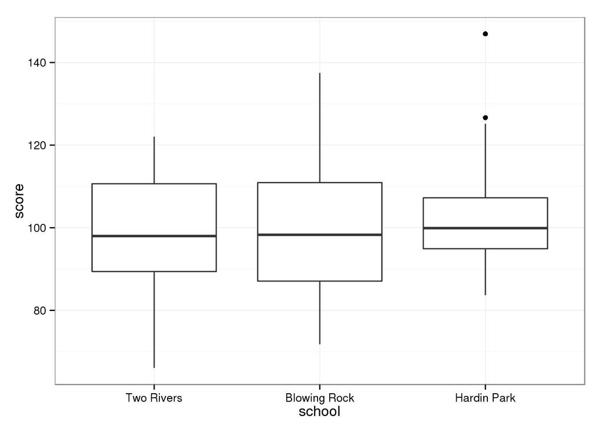

```r
ggplot(data = DF2, aes(x = school, y = score)) +
  geom_boxplot() +
  theme_bw()
```

```r
mod <- aov(score ~ school, data = DF2)
AR <- summary(mod)
AR
```

```
            Df Sum Sq Mean Sq F value Pr(>F)
school       2    482   241.0   1.027  0.363
Residuals   72  16885   234.5
```

- Statistical conclusion: fail to reject the null hypothesis.
- English conclusion: not enough evidence to suggest an association between average IQ and school district exists.

Post Hoc Tests:

```r
TukeyHSD(mod)
```

```
  Tukey multiple comparisons of means
    95% family-wise confidence level

Fit: aov(formula = score ~ school, data = DF2)

$school
                             diff       lwr      upr     p adj
Blowing Rock-Two Rivers  2.589477 -7.776205 12.95516 0.8217173
Hardin Park-Two Rivers   6.182141 -4.183541 16.54782 0.3324063
Hardin Park-Blowing Rock 3.592664 -6.773018 13.95835 0.6860794
```

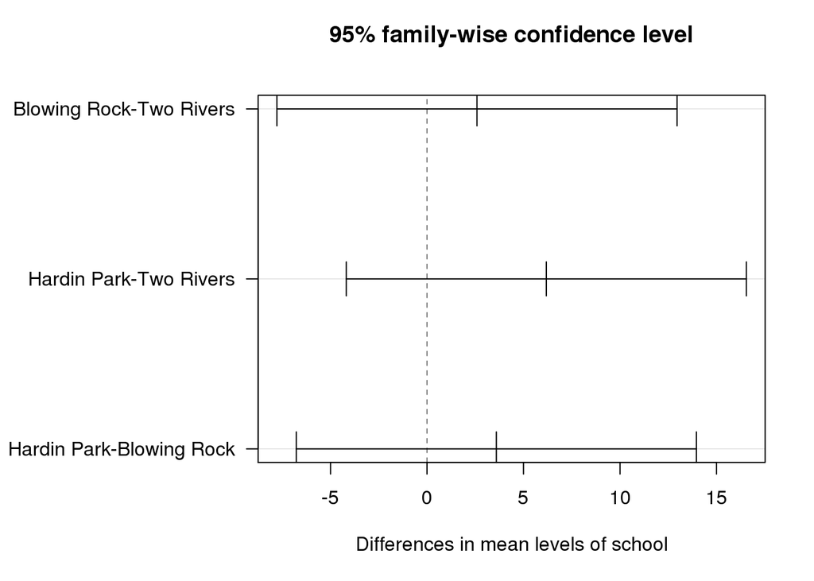

```r
opar <- par(no.readonly = TRUE)
par(mar = c(5.1, 11.1, 4.1, 2.1), las = 1) # Enlarge left margin
plot(TukeyHSD(mod))
```

```r
par(opar)  # return to defaults
```